# MileStoneReport

KunZhu

September 3, 2016

This milestone reported is produced fullfill the requirement of Data Science Specialization Capstone offered by Johns Hopkins University on Coursera. The purpose of this report is to document the initial tasks to prepare the data and perform exploratory analysis.

### Data Retrieving

The raw data is downloaded from HC Corpora via the link. The datasets in English are studied in this project.

```r
suppressWarnings(library("stringi"))
suppressWarnings(library(ggplot2))
suppressWarnings(library(tm))
suppressWarnings(library(slam))
suppressWarnings(library(wordcloud))

fileLink <- "https://d396qusza40orc.cloudfront.net/dsscapstone/dataset/Coursera-SwiftKey.zip"
filePath <- "~/Coursera-SwiftKey.zip"
if(!file.exists(filePath)) {
    download.file(fileLink, destfile = filePath)
    unzip(filePath)
    }
```

### Loading data and preprocessing

The exploratory analysis results of data from each txt file are presented in this sections.

```r
blogs <- readLines("/Users/KunZhu/Dropbox/Coursera/final/en_US/en_US.blogs.txt")
news <- readLines("/Users/KunZhu/Dropbox/Coursera/final/en_US/en_US.news.txt")
tw <- readLines("/Users/KunZhu/Dropbox/Coursera/final/en_US/en_US.twitter.txt")
```

The line and character statistics for the data are presented below:

```r
stri_stats_general(blogs)
```

```
##       Lines LinesNEmpty       Chars CharsNWhite
##      899288      899288   206824382   170389539
```

```r
stri_stats_general(news)
```

```
##       Lines LinesNEmpty       Chars CharsNWhite
##     1010242     1010242   203223154   169860866
```

```r
stri_stats_general(tw)
```

```
##       Lines LinesNEmpty       Chars CharsNWhite
##     2360148     2360148   162096031   134082634
```

The histogram of the word counts are presented below:

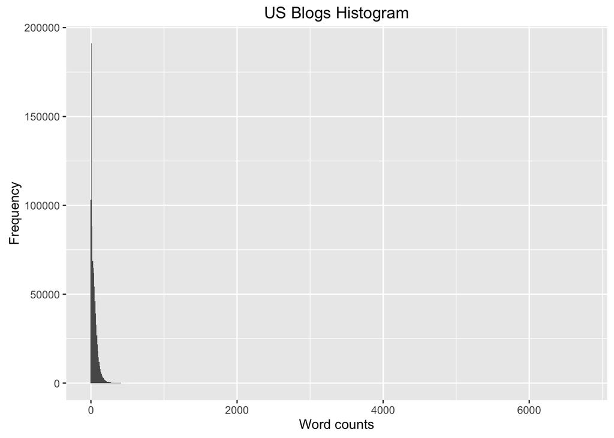

```r
wordSummary<-lapply(list(blogs, news, tw), function(x) stri_count_words(x))

qplot(wordSummary[[1]], geom="histogram", main="US Blogs Histogram",  xlab="Word counts", ylab="Frequency", binwidth = 8)
```

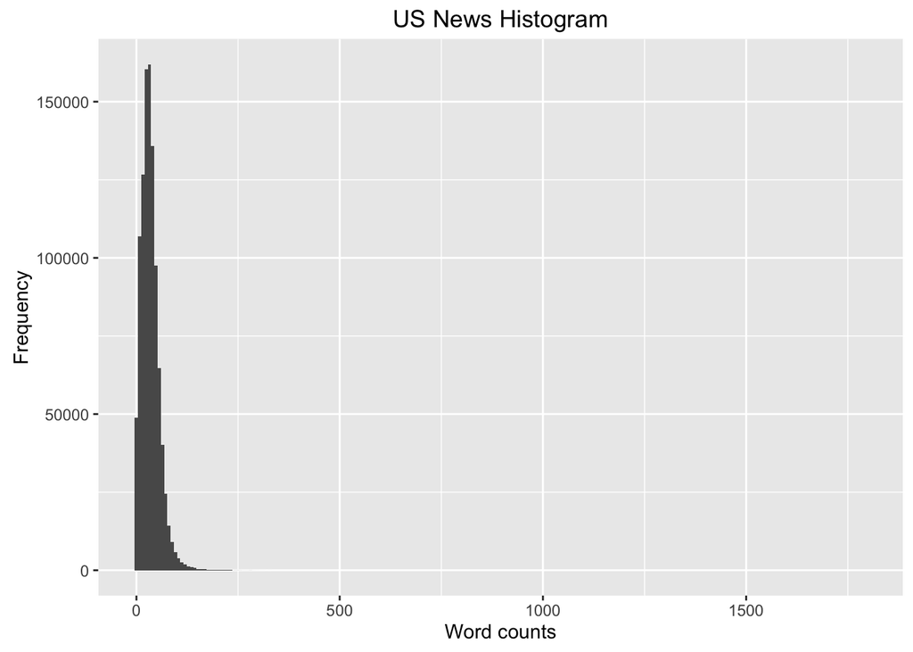

```r
qplot(wordSummary[[2]], geom="histogram", main="US News Histogram",  xlab="Word counts", ylab="Frequency", binwidth = 8)
```

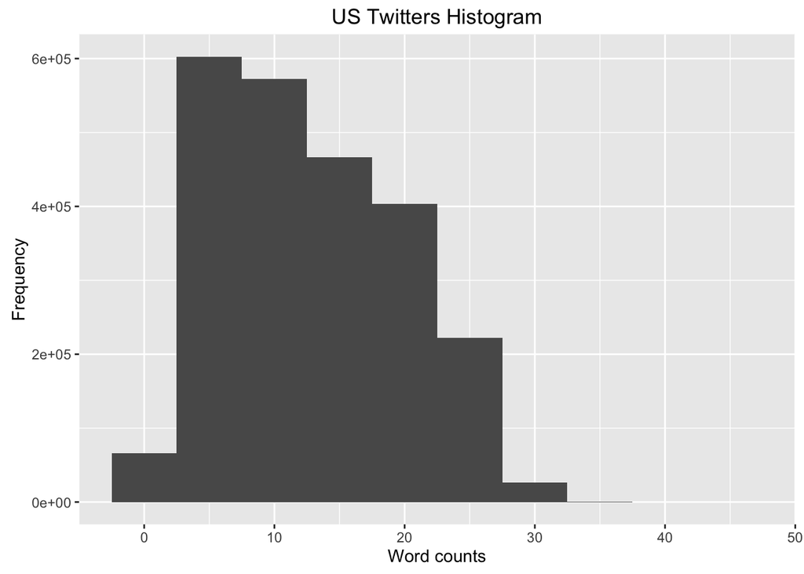

```r
qplot(wordSummary[[3]], geom="histogram", main="US Twitters Histogram",  xlab="Word counts", ylab="Frequency", binwidth = 5)
```

### Clean and build data corpus

```r
writeLines(c(blogs[sample(1:length(blogs), 8000)], news[sample(1:length(news), 8000)], tw[sample(1:length(tw), 8000)]), "/Users/KunZhu/Dropbox/Coursera/final/en_US/sampleText.txt")
```

```r
inputText <- readLines("/Users/KunZhu/Dropbox/Coursera/final/en_US/sampleText.txt")
badWords <- readLines("/Users/KunZhu/Dropbox/Coursera/final/en_US/bad.txt")
contentToLower <- content_transformer(tolower)

Corpus <- Corpus(VectorSource(inputText))
Corpus <- tm_map(Corpus, content_transformer(function(x, pattern) gsub(pattern, " ", x)), "/|@|\\|")
Corpus <- tm_map(Corpus, removePunctuation)
Corpus <- tm_map(Corpus, contentToLower)
Corpus <- tm_map(Corpus, stripWhitespace)
Corpus <- tm_map(Corpus, removeNumbers)
Corpus <- tm_map(Corpus, removeWords, badWords, lazy = TRUE)
```

### Analysis of Corpus

A word cloud is created for the readers to have a conceputal understanding of the content and high frequency words in the corpus. The most common words in the corpus are also the common words in the english language.

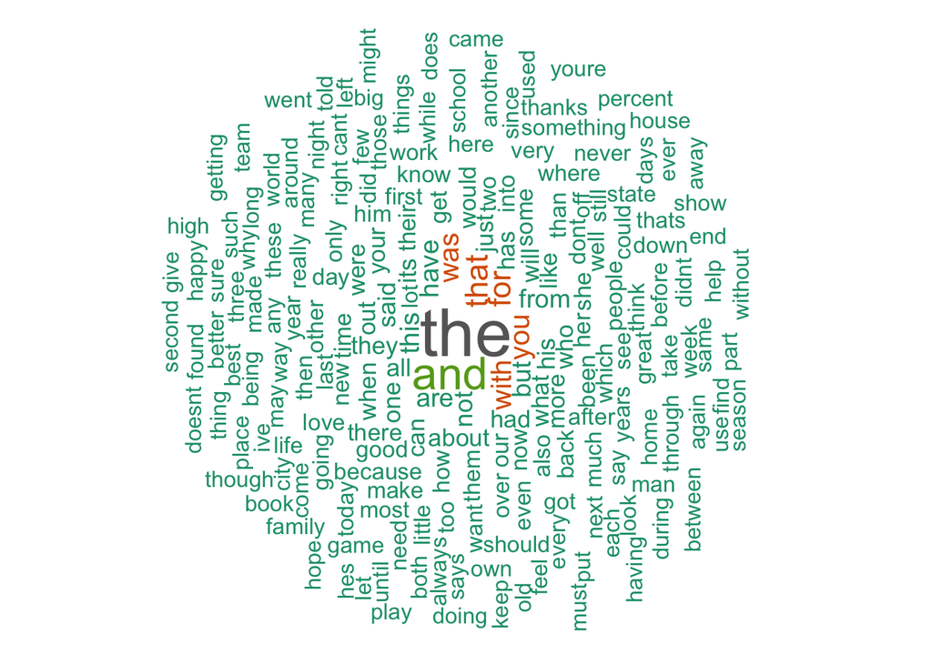

```r
sumRowCorpus <- row_sums(TermDocumentMatrix(Corpus))
freq <- sort(sumRowCorpus, decreasing = TRUE)
freq.name <- names(freq)
slab <- data.frame(wordName = freq.name, wordFreq = freq)
wordcloud(slab$wordName, slab$wordFreq, c(3, 1), rot.per= 0.75, max.words = 200, random.order = FALSE,  colors = brewer.pal(8, "Dark2"))
```

### Plans for the later tasks

The future tasks necessary to acomplish the project goal are to:

- Generating tokens of one to four words using n-grams
- Summarize and pruning (if necessary in case the performance is bad) token frequency
- Building a predictive model using the identified tokens
- Wrapping up the results and the developed model as a data product, shiny app.